# Cronus (dev)

#### Severe Malaria

##### .

```r
F_severe = function(acutePhase, PSYstates, trackV, params){
  UseMethod("F_severe", params$severePar)
}
```

##### Data

Severe malaria here includes all severe forms of malaria. It seems like it might be useful to consider severe malaria anemia as a separate issue. Lumping all severe malaria together, and crudely summarizing Figure 2 from Griffin, *et al* 2015, we can say:

- The total amount of severe malaria, summed over a lifetime, is at most 1 case per 3 individuals.
- The total amount of severe malaria is pretty flat across high-transmission settings
- In east African data, severe malaria peaks in the first year of life
- In the Gambia, severe malaria peaks around age 2

Replotting from Africa-Wide data tab from Supplement 2, from Griffin *et al.*, 2015.

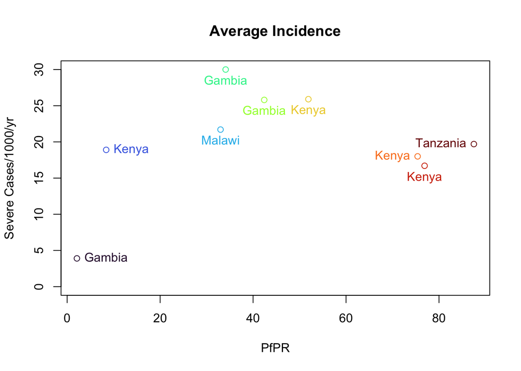

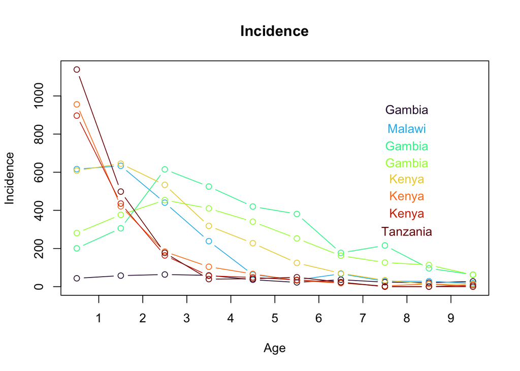

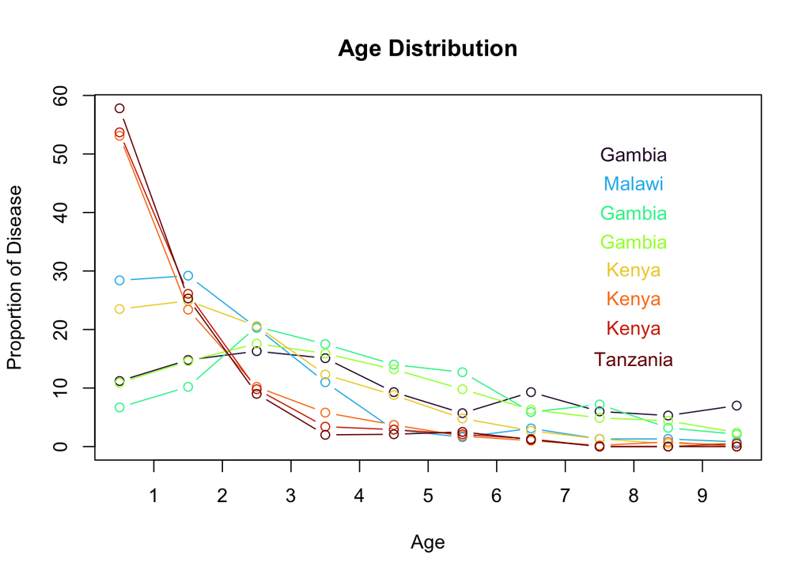

Using data from

- Griffin, J.T., Hollingsworth, T.D., Reyburn, H., Drakeley, C.J., Riley, E.M., and Ghani, A.C. (2015). Gradual acquisition of immunity to severe malaria with increasing exposure. Proceedings of the Royal Society of London B: Biological Sciences 282, 20142657–20142657.
- Carneiro, I., Roca-Feltrer, A., Griffin, J.T., Smith, L., Tanner, M., Schellenberg, J.A., Greenwood, B., and Schellenberg, D. (2010). Age-patterns of malaria vary with severity, transmission intensity and seasonality in sub-Saharan Africa: a systematic review and pooled analysis. PLoS One 5, e8988..

##### basic

We assume that maternal antibodies provide some degree of protection from severe malaria. We let `trackV[1]` be maternal protection, and we assume it is linked to the number of severe phenotypes, `N`

```r
F_severe.basic = function(acutePhase, PSYstates, trackV, params){with(params$severePar,{
    ScaleSevere/NSeverePhenotypes*exp(-(trackV[1] + trackV[3])/NSeverePhenotypes)*acutePhase
})}
```

```r
makePar_severeMalaria_cronus_basic = function(params){
  severePar = list()
  class(severePar) <- "basic"
  severePar$ScaleSevere = .3
  severePar$NSeverePhenotypes = 20
  params$severePar = severePar
  return(params)
}
```

```r
params = makePar_severeMalaria_cronus_basic(params)
```

##### jmh1

##### Mini

```r
F_severe(.1, NULL, c(1,0,1), params)
```

```r
updateCronus_mini_severe = function(eir, states){with(states,{
  alpha = 1-dnbinom(0, mu=eir, size=0.1)
  states$Severe = sum(F_severe(alpha, NULL, trackV, params))
  states$trackV[1] = params$dkMaternal*trackV[1]
  states$trackV[2] = trackV[2] + eir
  states$trackV[3] = trackV[2] + alpha
  return(states)
})}
```

```r
makeStates = function(params, Md=2, N=10){
  states = list()
  states$dkMaternal = .95
  states$trackV=rep(0,3)
  states$trackV[1]=N/Md
  states$params = params
  states$params$severePar$NSeverePhenotypes = N
  return(states)
}
```

```r
eir = 20/365
states = makeStates(params, N=3)
Severe = c()
aget = c(1:365)
for(i in aget){
  states = updateCronus_mini_severe(eir, states)
  Severe = c(Severe, states$Severe)
}
plot(10*aget/365, Severe*36.5*1000, type = "l", ylab = "Incidence / 1,000 pop / year", xlab = "Age (Years)")
```

[output not shown]

#### Objective Fever

##### .

This adds objective fever linked to acute phase infections, but it does not include an effect related to parasite densities.

```r
F_objectiveFever = function(acutePhase, PSYstates, trackV, params){
  UseMethod("F_objectiveFever", params$objectiveFeverPar)
}
```

##### basic

```r
F_objectiveFever.basic = function(acutePhase, PSYstates, trackV, params){with(params$objectiveFeverPar,{
   scaleObjectiveFever/NobjectiveFeverPhenotypes*exp(-(trackV[2] + trackV[3])/NobjectiveFeverPhenotypes)*acutePhase
})}
```

```r
makePar_objectiveFever_cronus_basic = function(params){
  objectiveFeverPar = list()
  class(objectiveFeverPar) <- "basic"
  objectiveFeverPar$scaleObjectiveFever = 1
  objectiveFeverPar$NobjectiveFeverPhenotypes = 40
  params$objectiveFeverPar = objectiveFeverPar
  return(params)
}
```

```r
params=makePar_objectiveFever_cronus_basic(params)
```

##### Mini

```r
F_objectiveFever(.1, NULL, c(1,0,1), params)
```

```r
updateCronus_mini_objectiveFever = function(eir, states){with(states,{
  alpha = 1-dnbinom(0, mu=eir, size=0.1)
  states$objectiveFever = F_objectiveFever(alpha, NULL, trackV, params)
  states$trackV[1] = dkMaternal*trackV[1]
  states$trackV[2] = trackV[2] + eir
  states$trackV[3] = trackV[2] + alpha
  return(states)
})}
```

```r
makeStates = function(params, Md=2, N=10){
  states = list()
  states$dkMaternal = .95
  states$trackV=rep(0,3)
  states$trackV[1]=N/Md
  states$params = params
  states$params$objectiveFeverPar$NobjectiveFeverPhenotypes = N
  return(states)
}
```

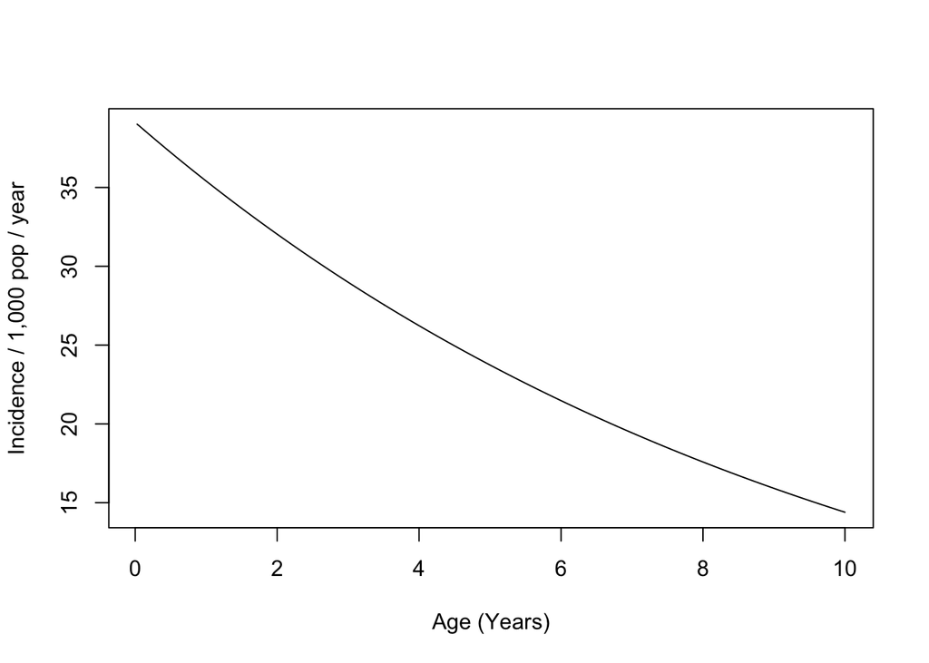

```r
eir = 20/365
states = makeStates(params, N=40)
objectiveFever = c()
aget = c(1:365)
for(i in aget){
  states = updateCronus_mini_objectiveFever(eir, states)
  objectiveFever = c(objectiveFever, states$objectiveFever)
}
plot(10*aget/365, objectiveFever*36.5*1000, type = "l", ylab = "Incidence / 1,000 pop / year", xlab = "Age (Years)")
```

#### Subjective Fever

##### .

Should this look like objective fever or not?

```r
F_subjectiveFever = function(acutePhase, PSYstates, trackV, params){
  UseMethod("F_subjectiveFever", params$subjectiveFeverPar)
}
```

##### basic

```r
F_subjectiveFever.basic = function(acutePhase, PSYstates, trackV, params){
    params$subjectiveFeverPar$backgroundsubjectiveFever*acutePhase
}
```

```r
makePar_subjectiveFever_cronus_basic = function(params){
  params$subjectiveFeverPar = list()
  class(params$subjectiveFeverPar) <- "basic"
  params$subjectiveFeverPar$backgroundsubjectiveFever=0.1
  return(params)
}
```

```r
params = makePar_subjectiveFever_cronus_basic(params)
```

##### jmh1

#### Anemia

Maybe soon.

### Drugs

#### .

We need to model care seeking, treating and curing, and chemoprotection

#### Seek Care

##### .

```r
F_seekCare = function(severe, objectiveFever, subjectiveFever, params){
  UseMethod("F_seekCare", params$seekCarePar)
}
```

##### basic

```r
F_seekCare.basic = function(severe, objectiveFever, subjectiveFever, params){with(params$seekCarePar,{
  seek = prSevere*severe
  seek = seek + (1-seek)*prObjective*objectiveFever
  seek = seek + (1-seek)*prSubjective*subjectiveFever
  return(seek)
})}
```

```r
makePar_seekCare_cronus_basic = function(params){
  params$seekCarePar = list()
  class(params$seekCarePar) <- "basic"
  params$seekCarePar$prSevere = 0.8
  params$seekCarePar$prObjective = 0.2
  params$seekCarePar$prSubjective = 0.05
  return(params)
}
```

```r
params = makePar_seekCare_cronus_basic(params)
```

##### jmh1

#### Rx

##### .

```r
F_treatCureRx = function(seekCare, params){
  UseMethod("F_treatCureRx", params$RxPar)
}
```

##### basic

```r
F_treatCureRx.basic = function(seekCare, params){
  return(params$RxPar$fullyTreat*seekCare)
}
```

```r
makePar_treatCureRx_cronus_basic = function(params){
  params$RxPar = list()
  class(params$RxPar) <- "basic"
  params$RxPar$fullyTreat = 0.8
  return(params)
}
```

```r
params = makePar_treatCureRx_cronus_basic(params)
```

##### jmh1

### Clearing

#### .

```r
F_persist = function(acutePhase, PSYstates, trackV, params){
  UseMethod("F_persist", params$persistPar)
}
```

#### basic

```r
F_persist.basic = function(acutePhase, PSYstates, trackV, params){
   with(params$persistPar,rep(exp(-rtau), params$nYstates))
}
```

```r
makePar_persistPf_cronus_basic = function(params){
  persistPar = list()
  class(persistPar) <- "basic"
  persistPar$rtau = 10/200
  params$persistPar = persistPar
  return(params)
}
```

```r
params = makePar_persistPf_cronus_basic(params)
```

#### jmh1

### Infectiousness

#### .

```r
F_kappa = function(acutePhase, PSYstates, trackV, params){
  UseMethod("F_kappa", params$kappa)
}
```

#### basic

```r
F_kappa.basic = function(acutePhase, PSYstates, trackV, params){
  params$kappa$NI
}
```

```r
makePar_kappa_cronus_basic = function(params){
  kappa = list()
  class(kappa) <- "basic"
  kappa$NI = 0.1
  params$kappa = kappa
  return(params)
}
```

```r
params = makePar_kappa_cronus_basic(params)
```

## Dynamics

### `wtXage`

```r
wtXage = function(age, mx = 1.4, shp=1000, flr = .2){
  (mx-flr)*age/(shp+age) + flr
}
```

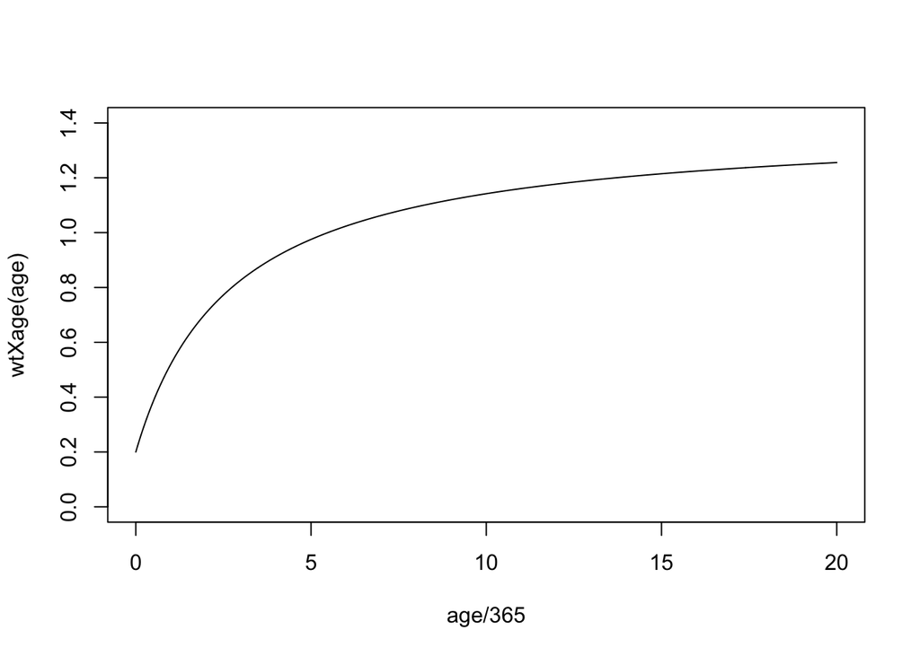

```r
age = seq(0, 7300, by = 10)
plot(age/365, wtXage(age), type = "l", ylim = range(0,1.4))
```

### `updateState`

```r
updateState = function(eir, states){with(states,{
  # age
  ageWt = wtXage(age)

  # Acute phase
  alpha_tlag2 = alpha_tlag1
  acutePhase = params$Susceptible2*PSYstates*alpha_tlag2

  # Latent phase
  alpha_tlag1 = alpha_t
  latentPhase = params$Susceptible1*PSYstates*alpha_tlag1

  # Current attack rate
  alpha_t = with(params, 1-dnbinom(0, mu=b*eir*ageWt, size=sz))


  # Compute moi, persistence
  Q = F_persist(acutePhase, PSYstates, trackV, params)


  # Compute kappa
  states$kappa = F_kappa(acutePhase, PSYstates, trackV, params)


  # Malaria
  severe          = F_severe(acutePhase, PSYstates, trackV, params)
  objectiveFever  = F_objectiveFever(acutePhase, PSYstates, trackV, params)
  subjectiveFever = F_subjectiveFever(acutePhase, PSYstates, trackV, params)
  seekCare        = F_seekCare(severe, objectiveFever, subjectiveFever, params)
  Rx              = F_treatCureRx(seekCare, params)

  ssm   = with(params, makeSSM(alpha_tlag2, Rx[-c(1:6)], Q, gamma_1, gamma_2, rho_S, rho_P, nAges))
  PSYstates = ssm %*% PSYstates

  #Tracking Variables
  states$trackV[1] = params$dkMaternal*trackV[1]
  states$trackV[2] = trackV[2] + eir
  states$trackV[3] = trackV[3] + sum(acutePhase)

  # Update States
  states$age             = age+10
  states$alpha_tlag2     = alpha_tlag2
  states$alpha_tlag1     = alpha_tlag1
  states$alpha_t         = alpha_t
  states$PSYstates       = PSYstates

  states$history$eir = c(states$history$eir, ageWt*eir)
  states$history$V1 = c(states$history$V1, states$trackV[1])
  states$history$V2 = c(states$history$V2, states$trackV[2])
  states$history$V3 = c(states$history$V3, states$trackV[3])
  states$history$severe = c(states$history$severe, as.vector(t(PSYstates) %*% severe*36.5*1000))
  states$history$objFever = c(states$history$objFever, as.vector(t(PSYstates) %*% objectiveFever))
  states$history$subjFever = c(states$history$subjFever, as.vector(t(PSYstates) %*%subjectiveFever))
  states$history$seekCare = c(states$history$seekCare, as.vector(t(PSYstates) %*% seekCare))
  states$history$treat = c(states$history$treat, as.vector(t(PSYstates)%*%Rx))

  return(states)
})}
```

### `makeParams_cronus`

```r
makeParams_cronus = function(nAges, Md=2){
  params = list()
  params$nAges = nAges
  params$nYstates = nAges
  params$ixY = 6 + c(1:nAges)
  params$alpha3 = .1
  params$gamma_1 = 0
  params$gamma_2 =1
  params$rho_S = 1/36.5
  params$rho_P = 1/36.5/5
  params$mu3 = 9/10
  params$sz = 1/10
  params$b = 0.55
  params$dkMaternal = .95
  params$Md = Md

  params = makePar_parasiteDensities_Cronus_basic(params)
  params = makePar_parasiteCounts_Cronus_basic(params)
  params = makePar_lightMicroscopy_cronus_basic(params)
  params = makePar_testByPCR_cronus_basic(params)
  params = makePar_testByRDT_cronus_basic(params)
  params = makePar_persistPf_cronus_basic(params)
  params = makePar_seekCare_cronus_basic(params)
  params = makePar_severeMalaria_cronus_basic(params)
  params = makePar_objectiveFever_cronus_basic(params)
  params = makePar_subjectiveFever_cronus_basic(params)
  params = makePar_treatCureRx_cronus_basic(params)
  params = makePar_kappa_cronus_basic(params)
  params$Susceptible1 = matrix(c(rep(0,3), rep(1, nAges+3)), ncol=1)
  params$Susceptible2 = matrix(c(rep(0,4), rep(1, nAges+2)), ncol=1)
  params$Susceptible3 = matrix(c(rep(0,5), rep(1, nAges+1)), ncol=1)
  return(params)
}
```

```r
makeParams_cronus(20) -> params
```

### `makeStates_cronus`

```r
makeStates_cronus = function(params){with(params,{
  states = list()
  states$age = 0
  states$params = params
  PSYstates = rep(0, nAges+6)
  PSYstates[4] = 1
  states$PSYstates = PSYstates

  trackV = c(0,0,0)
  trackV[1] = severePar$NSeverePhenotypes/Md
  states$trackV = trackV

  history = list()
  history$severe = 0
  history$objFever = 0
  history$subjFever = 0
  history$PfLM = 0
  history$PfRDT = 0
  history$PfPCR = 0
  history$treat = 0
  states$history = history

  return(states)
})}
```

### `cohort`

```r
eir = 10/365
params = makeParams_cronus(20, Md=5)
states = makeStates_cronus(params)
states$alpha_tlag1 = eir
states$alpha_t = eir
updateState(eir, states) -> states1
updateState(eir, states1) -> states2
```

```r
cohort_cronus = function(eir, nAges=20, maxAge=10, Md=5){
  params = makeParams_cronus(nAges, Md=Md)
  states = makeStates_cronus(params)
  states$alpha_tlag1 = 0
  states$alpha_t = eir
  age = 0
  while(age < maxAge*365){
    age = age+10
    updateState(eir, states) -> states
  }
  states$history$age = seq(0, age, by=10)
  return(states)
}
```

```r
Mdd = 5
cohort_cronus(1/36.5, 20, 20, Mdd) -> cohort1
cohort_cronus(3/36.5, 20, 20, Mdd) -> cohort3
cohort_cronus(9/36.5, 20, 20, Mdd) -> cohort9
cohort_cronus(27/36.5, 20, 20, Mdd) -> cohort27
cohort_cronus(81/36.5, 20, 20, Mdd) -> cohort81
cohort_cronus(243/36.5, 20, 20, Mdd) -> cohort243
```

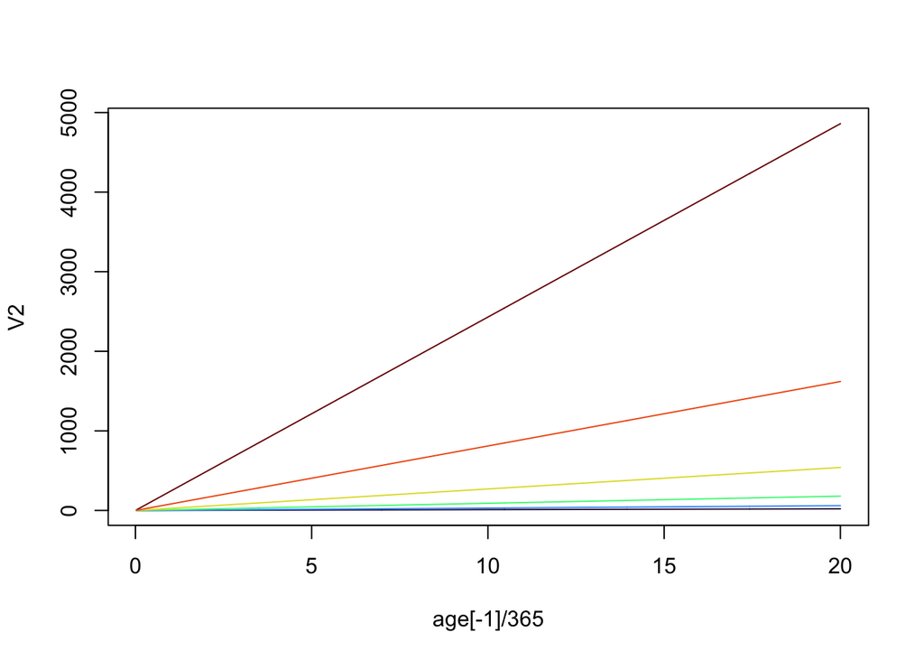

```r
clrs =  turbo(6)
with(cohort243$history, {
  plot(age[-1]/365, V2, type = "l", col = clrs[6])
})
with(cohort1$history, {
  lines(age[-1]/365, V2, type = "l", col = clrs[1])
})
with(cohort3$history, {
  lines(age[-1]/365, V2, type = "l", col = clrs[2])
})
with(cohort9$history, {
  lines(age[-1]/365, V2, type = "l", col = clrs[3])
})
with(cohort27$history, {
  lines(age[-1]/365, V2, type = "l", col = clrs[4])
})
with(cohort81$history, {
  lines(age[-1]/365, V2, type = "l", col = clrs[5])
})
```

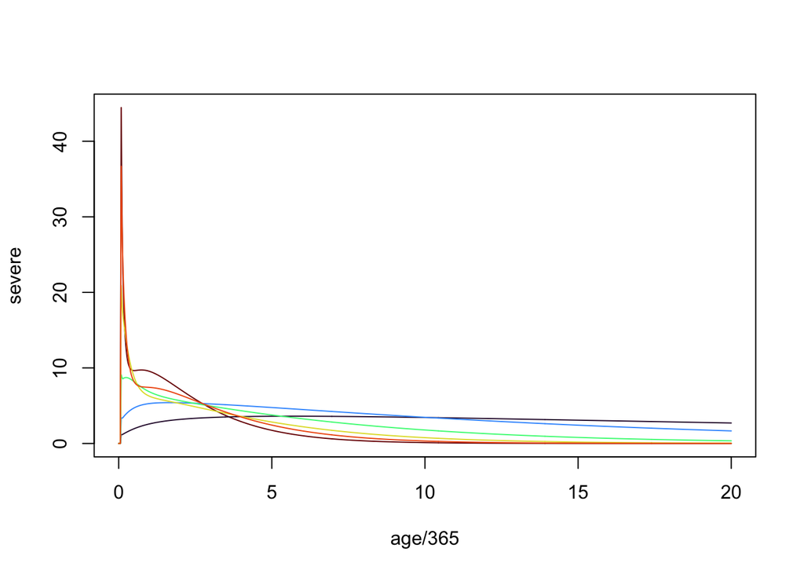

```r
clrs =  turbo(6)
with(cohort243$history, {
  plot(age/365, severe, type = "l", col = clrs[6])
})
with(cohort1$history, {
  lines(age/365, severe, type = "l", col = clrs[1])
})
with(cohort3$history, {
  lines(age/365, severe, type = "l", col = clrs[2])
})
with(cohort9$history, {
  lines(age/365, severe, type = "l", col = clrs[3])
})
with(cohort27$history, {
  lines(age/365, severe, type = "l", col = clrs[4])
})
with(cohort81$history, {
  lines(age/365, severe, type = "l", col = clrs[5])
})
```

```r
par(mfrow = c(3,3))
#plotHistory(cohort1)
```

## Full Model

Let $\cal X$ denote a matrix describing the full state space, which includes one vector for each cohort – the variables defining infection ($P$, $S$, $L$, $A$, $Y$ and $X$) and the immune tracking variables ($V$) – with multiple cohorts stacked in a matrix. Other notation is:

- $\cal M$ is the adult mosquito ecology model
- $\cal Z$ is the adult mosquito infection model
- $E$ is the EIR
- $\kappa$ is the net infectiousness

The full model in most of the estimation and fitting will be forced by an adult mosquito emergence rate, $\Lambda_t$. The full dynamics will look like this:

$$\begin{equation}
\begin{array}{rl}
{\cal M}_{t+1} &= F_{\cal M}({\cal M}_t, \Lambda_t) \\
{\cal Z}_{t+1} &= F_{\cal Z}({\cal Z}_t, {\cal M}_t, \kappa_t) \\
E_t &= F_E({\cal Z}_t) \\
{\cal X}_{t+1} &= F_{\cal X}({\cal X}_t, E_t) \\
\kappa_t &= F_\kappa({\cal X}_t) \\
\end{array}
\end{equation}$$